# Bridging

2025-03-13

# 1 Background

Our previous results of analyzing the discovery and validation dataset seperately were inconsistent The DE genes were completely different. Here we want to join / bridge the data from different batches.

# 2 Objectives

1. Bridge data

# 3 Conclusion

# 4 Pre-processing

## 4.1 Loading packages

```r
library(here)
library(tidyverse)
library(readxl)
library(readr)
library(stringr)
library(limma)
library(variancePartition)

library(tidyverse)
library(ggplot2)
library(patchwork)
library(ggrepel)
library(gghighlight)
library(ggbeeswarm)
library(VennDiagram)
library(ggvenn)


library(OlinkAnalyze)
library(paletteer)

# Survival
library(survival)
library(ggsurvfit)
library(survminer)
```

## 4.2 Directories

```r
wd <- list()
wd$main <- here()
wd$data <- file.path(wd$main, "data")
wd$manishData <- file.path(wd$data, "raw/data_fromManish")
wd$d2024 <- file.path(wd$data, "updated_2024")
wd$d2024_npx <- file.path(wd$d2024, "NPX_data")
wd$output <- file.path(wd$main, "output")
wd$script <- file.path(wd$main, "scripts")

wd$outData <- file.path(wd$output, "data")
wd$outCurr <- file.path(wd$output, "06_Bridging")

set.seed(123)
```

Create directories

```r
if (!file.exists(wd$outCurr)) {
  dir.create(wd$outCurr)
} else {
  print("Directory already exists")
}
```

```
## [1] "Directory already exists"
```

Load functions

```r
source(file.path(wd$script, "functions.R"))
```

## 4.3 Load data

Load the processed metadata file

```r
# TO DO - load the saved R object
load(file.path(wd$outData, "01_Metadata.Rdata"))
load(file.path(wd$outData, "02_data.Rdata"))
load(file.path(wd$outData, "04_data.Rdata"))
```

# 5 Obj 1: Clean up

We cleaned up the Psomagen dataset. Now lets clean up the other two datasets

### 5.0.1 Q-1335

We just read the mCRPC project for now (Tab 4 of the excel file)

```r
# Read in the Q-1335 metadata
meta_q1335 <- read_excel(meta_file, sheet = 4) %>%
  select('Sample ID (validation)', 'MRN (UUHSC)', 'Death date', 'Deceased?', 'Sample 1 Date',
         'sample1_psa', 'sample1_ldh', 'sample1_alk_phos') %>%
  rename(mrn = 'MRN (UUHSC)',
         sample_id = 'Sample ID (validation)',
         death_date = 'Death date',
         death = 'Deceased?',
         collection_date = 'Sample 1 Date',
         psa = 'sample1_psa',
         ldh = 'sample1_ldh',
         alk_ph = 'sample1_alk_phos') %>%
  mutate(death = gsub("Yes", "Y", death))

# Censor the date
meta_q1335$death_date[is.na(meta_q1335$death_date)] <- censor_date

# Calulate OS in months
meta_q1335 <- meta_q1335 %>%
  mutate(OS = as.numeric(difftime(death_date, collection_date, units = "days")),
         OS = round(OS/30.417, digit=2),
         death = case_when(death == "N" ~ 0,
                           death == "Y" ~ 1),
         sample_id = as.character(sample_id))
```

Read in the NPX data

```r
df_meta2 <- df_meta_f %>%
  filter(!is.na(sample_id_Q13356)) %>%
  # remove serial samples
  #filter(!HCI_cID %in% serial_sam) %>%
  dplyr::rename(SampleID = sample_id_Q13356) %>%
  select(cohort, SampleID) %>%
  distinct() %>%
  mutate(SampleID = as.character(SampleID))

# This removes conttol samples as well
dat2_NPX_anno <- dat_NPX2 %>%
  mutate(SampleID = as.character(SampleID)) %>%
  dplyr::left_join(df_meta2) %>%
  filter(!is.na(cohort))
```

#### 5.0.1.1 Assay outlier

We check if any samples were considered outlier in all of the 8 panels

```r
outliers_qc_labeled <- dat2_NPX_anno |>
  olink_qc_plot(outlierLines = FALSE, label_outliers = TRUE)
```

```
## 2 assay(s) exhibited assay QC warning. For more information see the Assay_Warning column.
```

```r
dat_outlier <- outliers_qc_labeled$data

sam_outlier <- dat_outlier %>% group_by(SampleID, Outlier) %>%
  count() %>%
  filter(Outlier == 1) %>%
  arrange(desc(n))
head(sam_outlier)
```

```
## # A tibble: 5 × 3
## # Groups:   SampleID, Outlier [5]
##   SampleID Outlier     n
##   <chr>      <dbl> <int>
## 1 45             1     8
## 2 77             1     8
## 3 54             1     2
## 4 59             1     2
## 5 37             1     1
```

We exclude two sampels that were deemed outlier in all 8 panel

```r
all_fail <- sam_outlier %>% filter(n==8)
dat2_final <- dat2_NPX_anno %>%
  filter(!SampleID %in% all_fail$SampleID)
```

#### 5.0.1.2 Protein outlier

We want to check if any proteins needs to be excluded. Olink provides a collumn called “QC_Warning” that we can use to determine.

```r
warn_assay <- dat2_final %>% filter(Assay_Warning == "WARN") %>% select(Assay, OlinkID) %>% distinct()
```

Or we can determine what number of samples are expressing the protein above the limit of detection

```r
numSample1 <- length(unique(dat2_final$SampleID))

dat2_missing <- dat2_final %>%
  group_by(OlinkID) %>%
  summarise(PercMissing = (sum(NPX < LOD) / numSample1) * 100) %>%
  mutate(Group = "Q_1335")
```

Lets retain all the proteins with less than 80% missing-ness

```r
assay_keep_2 <- dat2_missing %>%
  filter(PercMissing <= 80)  %>%
  filter(!OlinkID %in% warn_assay$OlinkID)
length(unique(assay_keep_2$OlinkID))
```

```
## [1] 2822
```

Lets subset the NPX data frame to these proteins

```r
dat2_final <- dat2_final %>%
  filter(OlinkID %in% assay_keep_2$OlinkID)
```

### 5.0.2 PCA

Lets look at the data PCA plot

```
## 0 assay(s) exhibited assay QC warning. For more information see the Assay_Warning column.
```

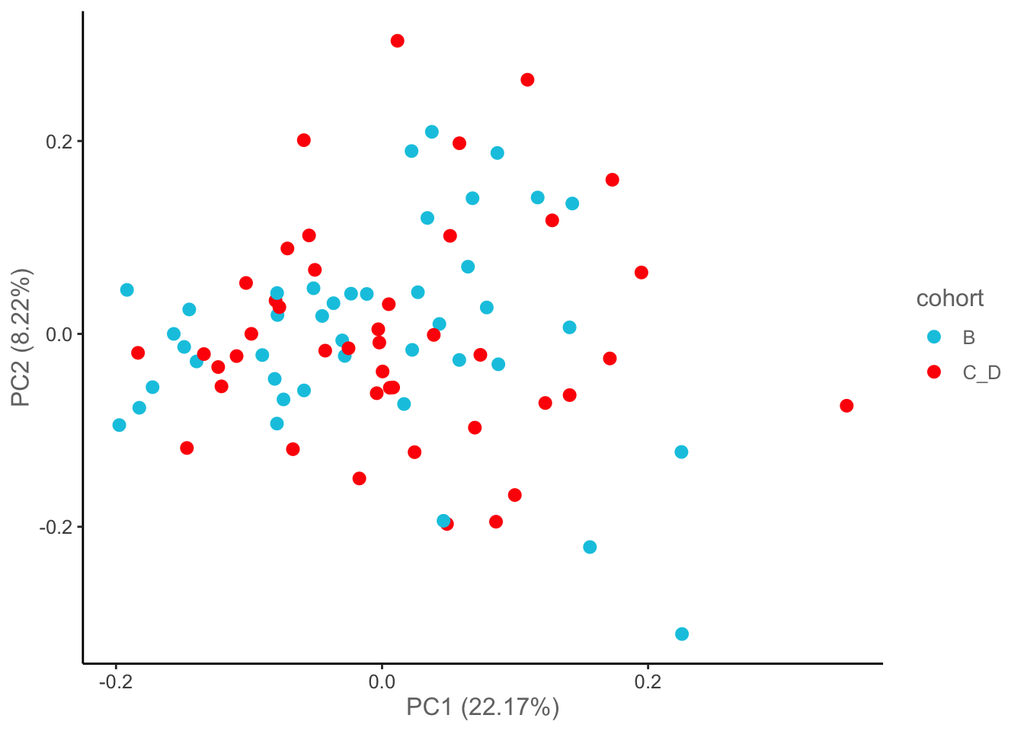

```r
dat2_pca <-
  dat2_final %>%
  filter(!str_detect(SampleID, 'CS')) %>%
  olink_pca_plot(df = .,
                 color_g = "cohort", byPanel = FALSE, quiet = FALSE)
```

### Q-15806

```r
meta_q1580 <- read_excel(meta_file, sheet = 7) %>%
  select('Plate_4_pt_ID', 'MRN (UUHSC)', 'Death date', 'Deceased?', 'Sample1_date',
         'sample1_psa', 'sample1_ldh', 'sample1_alk_phos') %>%
  rename(mrn = 'MRN (UUHSC)',
         sample_id = 'Plate_4_pt_ID',
         death_date = 'Death date',
         death = 'Deceased?',
         collection_date = 'Sample1_date',
         psa = 'sample1_psa',
         ldh = 'sample1_ldh',
         alk_ph = 'sample1_alk_phos')

# Censor the date
meta_q1580$death_date[is.na(meta_q1580$death_date)] <- censor_date

# Calulate OS in months
meta_q1580 <- meta_q1580 %>%
  mutate(OS = as.numeric(difftime(death_date, collection_date, units = "days")),
         OS = round(OS/30.417, digit=2),
         death = case_when(death == "No" ~ 0,
                           death == "Yes" ~ 1),
         sample_id = as.character(sample_id))
```

Read in the NPX data

```r
df_meta3 <- df_meta_f %>%
  filter(!is.na(sample_id_Q15806)) %>%
  # remove serial samples
  #filter(!HCI_cID %in% serial_sam) %>%
  dplyr::rename(SampleID = sample_id_Q15806) %>%
  select(cohort, SampleID) %>%
  distinct() %>%
  mutate(SampleID = as.character(SampleID))

# This removes conttol samples as well
dat3_NPX_anno <- dat_NPX3 %>%
  mutate(SampleID = as.character(SampleID)) %>%
  dplyr::left_join(df_meta3) %>%
  filter(!is.na(cohort))
```

#### 5.0.2.1 Assay outlier

We check if any samples were considered outlier in all of the 8 panels

```r
outliers_qc_labeled <- dat3_NPX_anno |>
  olink_qc_plot(outlierLines = FALSE, label_outliers = TRUE)
```

```
## 9 assay(s) exhibited assay QC warning. For more information see the Assay_Warning column.
```

```r
dat_outlier <- outliers_qc_labeled$data

sam_outlier <- dat_outlier %>% group_by(SampleID, Outlier) %>%
  count() %>%
  filter(Outlier == 1) %>%
  arrange(desc(n))
head(sam_outlier)
```

```
## # A tibble: 4 × 3
## # Groups:   SampleID, Outlier [4]
##   SampleID Outlier     n
##   <chr>      <dbl> <int>
## 1 2              1     8
## 2 49             1     8
## 3 71             1     7
## 4 4              1     2
```

We exclude two samples that were deemed outlier in all 8 panel

```r
all_fail <- sam_outlier %>% filter(n==8)
dat3_final <- dat3_NPX_anno %>%
  filter(!SampleID %in% all_fail$SampleID)
```

#### 5.0.2.2 Protein outlier

We want to check if any proteins needs to be excluded. Olink provides a collumn called “QC_Warning” that we can use to determine.

```r
warn_assay <- dat3_final %>% filter(Assay_Warning == "WARN") %>% select(Assay, OlinkID) %>% distinct()
```

Or we can determine what number of samples are expressing the protein above the limit of detection

```r
numSample1 <- length(unique(dat3_final$SampleID))

dat3_missing <- dat3_final %>%
  group_by(OlinkID) %>%
  summarise(PercMissing = (sum(NPX < LOD) / numSample1) * 100) %>%
  mutate(Group = "Q_1580")
```

Lets retain all the proteins with less than 80% missing-ness

```r
assay_keep_3 <- dat3_missing %>%
  filter(PercMissing <= 80)  %>%
  filter(!OlinkID %in% warn_assay$OlinkID)
length(unique(assay_keep_3$OlinkID))
```

```
## [1] 2747
```

Lets subset the NPX data frame to these proteins

```r
dat3_final <- dat3_final %>%
  filter(OlinkID %in% assay_keep_3$OlinkID)
```

## 5.1 PCA

```
## 0 assay(s) exhibited assay QC warning. For more information see the Assay_Warning column.
```

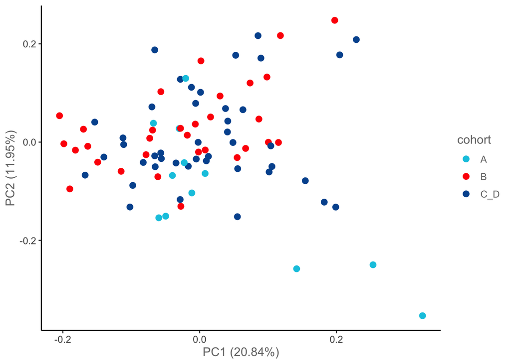

```r
dat3_pca <-
  dat3_final %>%
  filter(!str_detect(SampleID, 'CS')) %>%
  olink_pca_plot(df = .,
                 color_g = "cohort", byPanel = FALSE, quiet = FALSE)
```

We see an extreme plot of 3 samples from cohort A. Lets explore further.

Lets gather all cohort A samples, then check the NPX distribution

```r
dat3_final_A <- dat3_final %>% filter(cohort == "A")

# Get the PCA coordinate to identify these sanmples
pca_cor_bridge <- dat3_pca[[1]]$data %>%
  rename(PC1 = PCX,
         PC2 = PCY) %>%
  mutate(outlier = case_when(
    colors == "A" & PC1 >= 0.1 ~ "Outlier",
    TRUE ~ "Keep"
  ))
rmv_sam <- pca_cor_bridge %>% filter(outlier == "Outlier") %>% pull(SampleID)
rmv_sam
```

```
## [1] "61" "63" "71"
```

```
## 0 assay(s) exhibited assay QC warning. For more information see the Assay_Warning column.
```

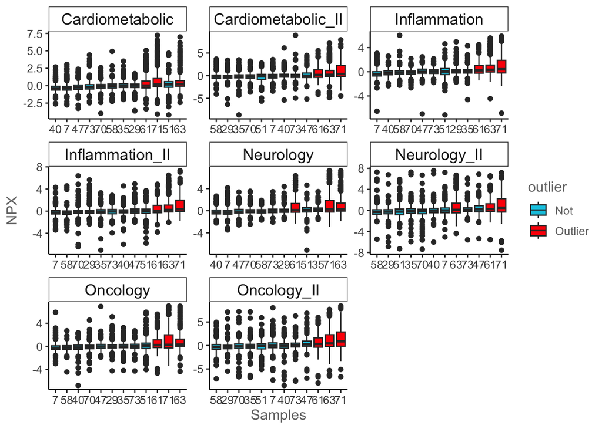

```r
# Label
dat3_final_A <- dat3_final_A %>% mutate(outlier = case_when(SampleID %in% rmv_sam ~ "Outlier",
                                                                TRUE ~ "Not"))

# Check NPX distibution
dat3_final_A |>
  olink_dist_plot(color_g = "outlier")
```

These 3 samples have consistently higher NPX compared to other samples. So we remove them.

```r
dat3_final <- dat3_final %>%
  filter(!SampleID %in% rmv_sam)
```

Re-plot the PCA

```
## 0 assay(s) exhibited assay QC warning. For more information see the Assay_Warning column.
```

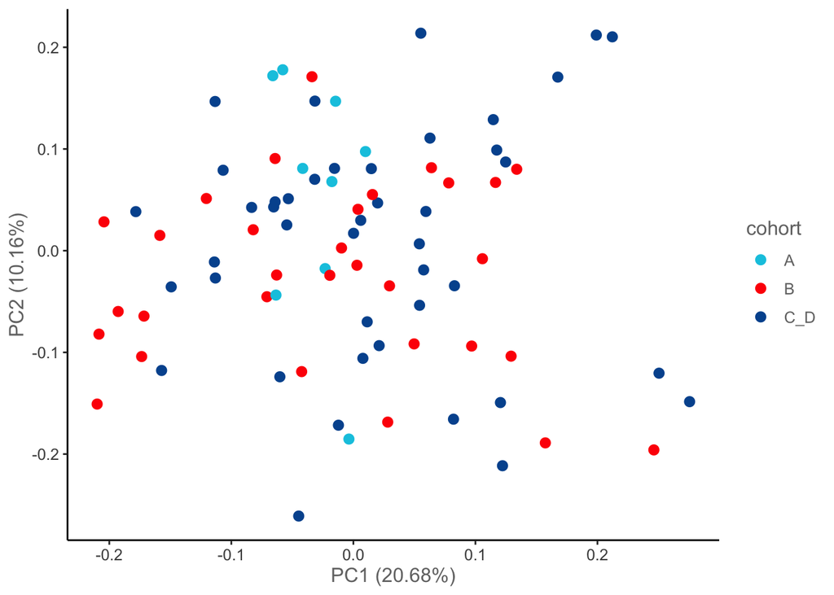

```r
dat3_pca_v2 <-
  dat3_final %>%
  filter(!str_detect(SampleID, 'CS')) %>%
  olink_pca_plot(df = .,
                 color_g = "cohort", byPanel = FALSE, quiet = FALSE)
```

## 5.2 Protein overlap

Lets get the overlap of proteins across 3 platforms

```r
un_a <- unique(dat1_final$OlinkID)
un_b <- unique(dat2_final$OlinkID)
un_c <- unique(dat3_final$OlinkID)

overlap <- calculate.overlap(
x <- list("Psomagen"=un_a,
          "Q-1335"=un_b,
          "Q-1580"=un_c))

pdf(file=file.path(wd$outCurr, "Protein_overlap.pdf"), width = 5, height = 5)
ggvenn(
  x,
  fill_color = df.pal.study$pal,
  show_percentage = FALSE,
  stroke_size = 0.5, set_name_size = 4
)
dev.off()
```

```r
ggvenn(
  x,
  fill_color = pal.study,
  show_percentage = FALSE,
  stroke_size = 0.5, set_name_size = 4
)
```

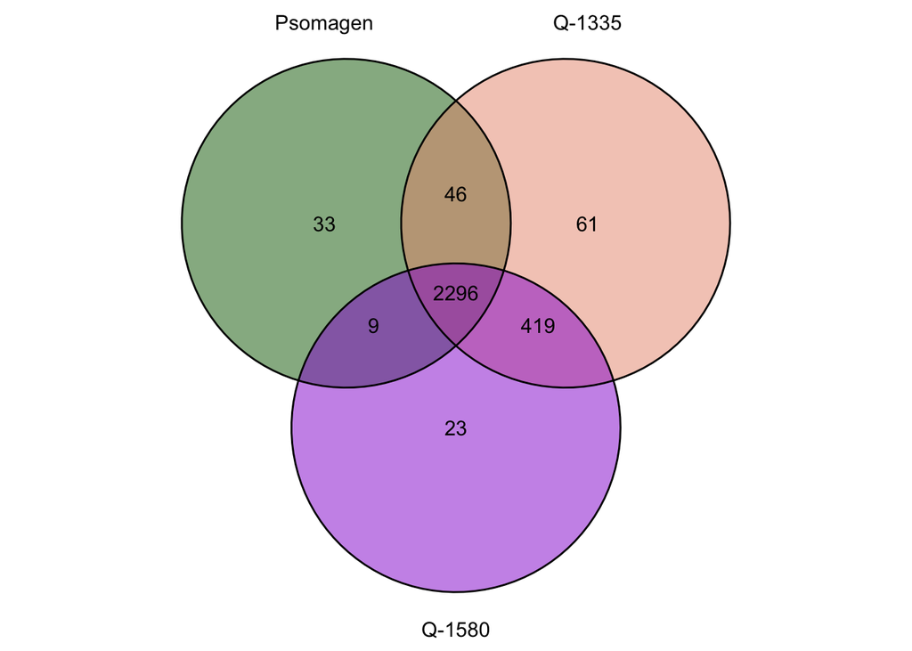

Save this list of proteins

> TO DO

> We filtered the samples and proteins. We will bridge the data using these proteins

# 6 Obj 2: Limma correction

We explore another methods to correct for the batch using limma

### 6.0.1 Data prep

```r
xx1 <- dat1_final
xx2 <- dat2_final
xx3 <- dat3_final
```

Convert to gene x matrix

```r
mat_olink1 <- xx1 %>%
  dplyr::select(SampleID, OlinkID, NPX) %>%
  # Remove contraol samples
  dplyr::filter(!str_detect(SampleID, 'CONTROL_SAMPLE')) %>%
  # Convert to wide
  tidyr::pivot_wider(names_from = SampleID, values_from = NPX)
colnames(mat_olink1)[2:ncol(mat_olink1)] <- paste0("Disc_", colnames(mat_olink1)[2:ncol(mat_olink1)] )

mat_olink2 <- xx2 %>%
  dplyr::select(SampleID, OlinkID, NPX) %>%
  # Remove contraol samples
  dplyr::filter(!str_detect(SampleID, 'CONTROL_SAMPLE')) %>%
  # Convert to wide
  tidyr::pivot_wider(names_from = SampleID, values_from = NPX)
colnames(mat_olink2)[2:ncol(mat_olink2)] <- paste0("Proj2_", colnames(mat_olink2)[2:ncol(mat_olink2)] )

mat_olink3 <- xx3 %>%
  dplyr::select(SampleID, OlinkID, NPX) %>%
  # Remove contraol samples
  dplyr::filter(!str_detect(SampleID, 'CONTROL_SAMPLE')) %>%
  # Convert to wide
  tidyr::pivot_wider(names_from = SampleID, values_from = NPX)
colnames(mat_olink3)[2:ncol(mat_olink3)] <- paste0("Proj4_", colnames(mat_olink3)[2:ncol(mat_olink3)] )
```

Selecting the genes

```r
# Create a matrix of just overlapping genes
int_ol <-
  Reduce(intersect, list(
  mat_olink1$OlinkID,
  mat_olink2$OlinkID,
  mat_olink3$OlinkID))

m1 <- mat_olink1 %>% as.data.frame()
rownames(m1) <- m1$OlinkID
m1 <- m1[int_ol,-1]

m2 <- mat_olink2 %>% as.data.frame()
rownames(m2) <- m2$OlinkID
m2 <- m2[int_ol,-1]

m3 <- mat_olink3 %>% as.data.frame()
rownames(m3) <- m3$OlinkID
m3 <- m3[int_ol,-1]


m_all <- cbind(m1, m2, m3)
```

### 6.0.2 Running limma

Here we use limma to correct the batch effects. First we create a data frame to indicate the replicates across experiments

```r
# Define the model formula
# Generate master replicate sheets
vector1 <- df_meta_f %>% filter(Psomagen == "Y") %>% pull(HCI_cID)
vector2 <- df_meta_f %>% filter(Q_13356 == "Y") %>% pull(HCI_cID)
vector3 <- df_meta_f %>% filter(Q_15806 == "Y") %>% pull(HCI_cID)

# Intersection of any two vectors
intersection_any <- union(intersect(vector1, vector2), union(intersect(vector1, vector3), intersect(vector2, vector3)))

# Bridge data
df_bridge <- df_meta_f %>%
  filter(HCI_cID %in% intersection_any) %>%
  select(HCI_cID, cohort, sample_id_psom, sample_id_Q13356, sample_id_Q15806) %>%
  mutate(Rep = as.character( sprintf("%02d" ,1:length(intersection_any))))

df_bridge2 <- data.frame(
  SampleID =
    c(paste(paste0("Disc_", df_bridge$sample_id_psom)),
      paste(paste0("Proj2_", df_bridge$sample_id_Q13356)),
      paste(paste0("Proj4_", df_bridge$sample_id_Q15806))),
  Rep = paste0("Rep_", df_bridge$Rep)) %>%
  filter(!str_detect(SampleID, "_NA"))

meta_data <- data.frame(
  SampleID = colnames(m_all),
  Batch = c(
    rep("Dis", each=ncol(m1)),
    rep("Proj_2", each=ncol(m2)),
    rep("Proj_4", each=ncol(m3))
)) %>% left_join(df_bridge2) %>%
  # Create replicate IDs
  # For technical replicates, use the same ID across runs
  mutate(ReplicateID = case_when(!is.na(Rep) ~ Rep,
                                 TRUE ~ SampleID))
head(meta_data)
```

```
##   SampleID Batch    Rep ReplicateID
## 1   Disc_1   Dis Rep_15      Rep_15
## 2   Disc_2   Dis   <NA>      Disc_2
## 3   Disc_3   Dis   <NA>      Disc_3
## 4   Disc_4   Dis   <NA>      Disc_4
## 5   Disc_5   Dis   <NA>      Disc_5
## 6   Disc_6   Dis   <NA>      Disc_6
```

```r
meta_data %>% filter(Rep == "Rep_15")
```

```
##   SampleID  Batch    Rep ReplicateID
## 1   Disc_1    Dis Rep_15      Rep_15
## 2  Proj2_4 Proj_2 Rep_15      Rep_15
```

```r
# Add cohort info
df_bridge <- df_meta_f %>%
  select(HCI_cID, cohort, sample_id_psom, sample_id_Q13356, sample_id_Q15806)

df_bridge2 <- data.frame(
  SampleID =
    c(paste(paste0("Disc_", df_bridge$sample_id_psom)),
      paste(paste0("Proj2_", df_bridge$sample_id_Q13356)),
      paste(paste0("Proj4_", df_bridge$sample_id_Q15806))),
  cohort = df_bridge$cohort,
  HCI_cID = df_bridge$HCI_cID) %>%
  filter(!str_detect(SampleID, "_NA"))

meta_data <- meta_data %>% left_join(df_bridge2)
#colnames(m_all) <- meta_data$ReplicateID
# Ensure that SampleID matches the columns in counts
stopifnot(all(meta_data$SampleID == colnames(m_all)))

# Ensure the samples are in the same order
meta_data <- meta_data[match(colnames(m_all), meta_data$SampleID), ]
# Verify the order matches
all(colnames(m_all) == meta_data$SampleID)  # Should return TRUE
```

```
## [1] TRUE
```

```r
rownames(meta_data) <- meta_data$SampleID

meta_data <- meta_data %>%
  mutate(cohort = factor(cohort),
         Batch = factor(Batch),
         ReplicateID = factor(ReplicateID))
```

Now lets perform the batch correction

```r
# Set up parallel processing (optional)
param <- SnowParam(4, "SOCK")  # Adjust the number of cores based on your system

design <- model.matrix(~ cohort, data = meta_data)

# Estimate within-replicate correlation
corfit <- duplicateCorrelation(m_all, design, block = meta_data$ReplicateID)

# Remove batch effects
exprMatrix_corrected <- removeBatchEffect(
  m_all,
  batch = meta_data$Batch,
  block = meta_data$ReplicateID,
  correlation = corfit$consensus
)
```

Vizualise the result before and after correlation

```r
pt_sz <- 2
# PCA before
# PCA before batch correction
pca_before <- prcomp(t(m_all), scale. = TRUE)
meta_data$PC1_before <- pca_before$x[,1]
meta_data$PC2_before <- pca_before$x[,2]

# Calculate variance explained
pc_variances <- pca_before$sdev^2
variance_explained <- pc_variances / sum(pc_variances)
percent_variance_explained <- variance_explained * 100

# Extract variance for PC1 and PC2
pc1_variance <- percent_variance_explained[1]
pc2_variance <- percent_variance_explained[2]

# Create labels for plotting
pc1_label <- paste0("PC1 (", round(pc1_variance, 2), "%)")
pc2_label <- paste0("PC2 (", round(pc2_variance, 2), "%)")


p1.1 <-
ggplot(meta_data, aes(x = PC1_before, y = PC2_before, color = Batch)) +
  geom_point(size = pt_sz) +
  labs(
    title = "PCA Before Batch Correction",
    x = pc1_label,
    y = pc2_label) +
  theme_bw() +
  theme_custom +
  theme(legend.position = "none") +
  scale_colour_manual(values = pal.study) +
  NULL


p1.2 <-
ggplot(meta_data, aes(x = PC1_before, y = PC2_before, color = cohort)) +
  geom_point(size = pt_sz) +
  labs(
    title = "PCA Before Batch Correction",
    x = pc1_label,
    y = pc2_label) +
  theme_bw() +
  theme_custom +
  theme(legend.position = "none") +
  scale_colour_manual(values = pal.cohort.n2) +
  NULL
```

## 6.1 Correlation plot

Get the correlation of all the samples.

```r
# Reshape the gene expression data for plotting
long_expr <- exprMatrix_corrected %>% as.data.frame() %>%
  rownames_to_column("Gene") %>%
  pivot_longer(cols = -Gene, names_to = "SampleID", values_to = "Expression")
```

Match replicates based on the replicate mapping

```r
replicate_pairs <- meta_data %>%
  filter(!is.na(Rep)) %>%
  inner_join(meta_data, by = "Rep") %>%
  filter(SampleID.x != SampleID.y) %>%
  select(Rep, SampleID.x, SampleID.y) %>%
  distinct()
dplyr::filter(replicate_pairs, SampleID.y == "Proj2_4")
```

```
##      Rep SampleID.x SampleID.y
## 1 Rep_15     Disc_1    Proj2_4
```

Loop to get the correlation values

> Run this just once

```r
# Cor-pair for each replicate
# Create an empty data frame to store correlation results
# Create an empty data frame to store correlation results
cor_results <- data.frame(
  Sample1 = character(),
  Sample2 = character(),
  Cohort1 = character(),
  Cohort2 = character(),
  Correlation = numeric(),
  Rep = character(),
  stringsAsFactors = FALSE
)

# Get all unique pairs of samples
sample_pairs <- expand.grid(SampleID_x = unique(long_expr$SampleID),
                            SampleID_y = unique(long_expr$SampleID),
                            stringsAsFactors = FALSE) %>%
  filter(SampleID_x < SampleID_y)  # Avoid duplicate pairs and self-comparisons

# Compute correlation for each pair
cor_results <- sample_pairs %>%
  rowwise() %>%
  mutate(
    cor_value = {
      df <- inner_join(
        long_expr %>% filter(SampleID == SampleID_x) %>% rename(Expression_x = Expression),
        long_expr %>% filter(SampleID == SampleID_y) %>% rename(Expression_y = Expression),
        by = "Gene"
      )

      cor(df$Expression_x, df$Expression_y, use = "pairwise.complete.obs")
    },
    Cohort1 = meta_data$cohort[meta_data$SampleID == SampleID_x],
    Cohort2 = meta_data$cohort[meta_data$SampleID == SampleID_y],
    Rep = ifelse(
      meta_data$Rep[meta_data$SampleID == SampleID_x] == meta_data$Rep[meta_data$SampleID == SampleID_y] &
        !is.na(meta_data$Rep[meta_data$SampleID == SampleID_x]),
      meta_data$Rep[meta_data$SampleID == SampleID_x],
      NA
    )
  ) %>%
  select(Sample1 = SampleID_x, Sample2 = SampleID_y, Cohort1, Cohort2, Correlation = cor_value, Rep)
```

We examine the correlation results.

```r
#cor_results_ori <- cor_results
cor_results <- read.csv(file.path(wd$outCurr, "Filtered_genes_LimmaCorrected_cor.csv"))
#write.csv(cor_results, file.path(wd$outCurr, "Filtered_genes_LimmaCorrected_cor.csv"))
```

```r
df_low <- cor_results %>% filter(!is.na(Rep)) %>% filter(Correlation <= 0.5)
tail(df_low)
```

```
##       X  Sample1  Sample2 Cohort1 Cohort2 Correlation    Rep
## 1 51678 Disc_103 Proj4_62     C_D     C_D   0.4229853 Rep_16
## 2 51799 Proj2_29 Proj4_62     C_D     C_D   0.2468438 Rep_16
## 3 58030  Disc_35 Proj4_72     C_D     C_D   0.4627674 Rep_10
## 4 58226 Proj2_14 Proj4_72     C_D     C_D   0.3603656 Rep_10
```

Identify the samples to be removed after correlation analysis

```r
df_low_sample <- unique(df_low$Sample2)
```

Re-run the entire workflow

```r
# Filter the meta data to remove the poor correlated samples
meta_data2 <- meta_data %>% filter(!SampleID %in% df_low_sample)

# Get the number of overlapping samples
rep_1 <- filter(meta_data2, Batch=="Dis") %>% pull(ReplicateID)
rep_2 <- filter(meta_data2, Batch=="Proj_2") %>% pull(ReplicateID)
rep_3 <- filter(meta_data2, Batch=="Proj_4") %>% pull(ReplicateID)


overlap <- calculate.overlap(
  x <- list(
    "Dis"=rep_1,
    "Q_13356"=rep_2,
    "Q_15806"=rep_3))

ggvenn(
  x,
  fill_color = pal.study,
  show_percentage = FALSE,
  stroke_size = 0.5, set_name_size = 4
)
```

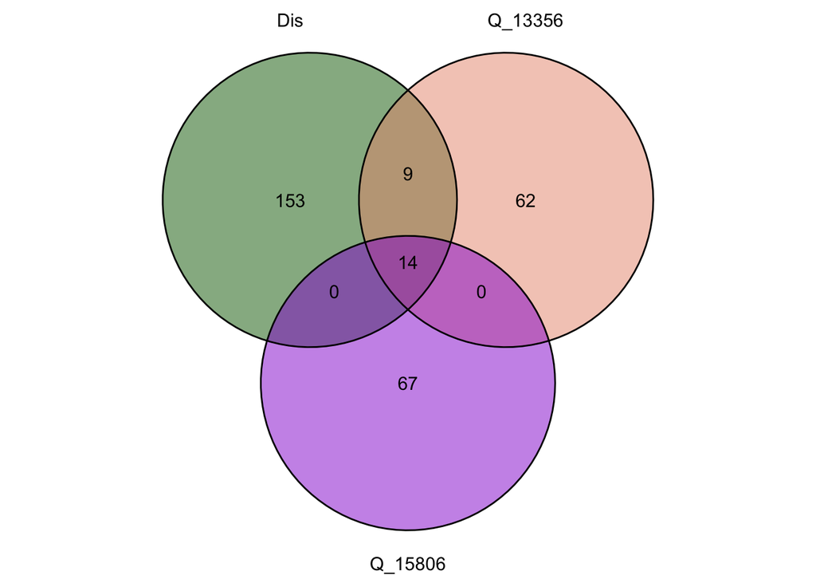

Run the correlation analysis

```r
# Remove the samples from the matrix
m_all2 <- m_all[,meta_data2$SampleID]

# Set up parallel processing (optional)
param <- SnowParam(4, "SOCK")  # Adjust the number of cores based on your system

design <- model.matrix(~ cohort, data = meta_data2)

# Estimate within-replicate correlation
corfit <- duplicateCorrelation(m_all2, design, block = meta_data2$ReplicateID)

# Remove batch effects
exprMatrix_corrected2 <- removeBatchEffect(
  m_all2,
  batch = meta_data2$Batch,
  block = meta_data2$ReplicateID,
  correlation = corfit$consensus
)
```

Lets re-do the correlation again, limited to those with Rep

```r
# Reshape the gene expression data for plotting
long_expr <- exprMatrix_corrected2 %>% as.data.frame() %>%
  rownames_to_column("Gene") %>%
  pivot_longer(cols = -Gene, names_to = "SampleID", values_to = "Expression")
```

Match replicates based on the replicate mapping

```r
replicate_pairs <- meta_data2 %>%
  filter(!is.na(Rep)) %>%
  inner_join(meta_data, by = "Rep") %>%
  filter(SampleID.x != SampleID.y) %>%
  select(Rep, SampleID.x, SampleID.y) %>%
  distinct()
long_expr <- long_expr %>% filter(SampleID %in%
                                    unique(c(replicate_pairs$SampleID.x, replicate_pairs$SampleID.y)))

# Cor-pair for each replicate
cor_results <- data.frame(
  Sample1 = character(),
  Sample2 = character(),
  Cohort1 = character(),
  Cohort2 = character(),
  Correlation = numeric(),
  Rep = character(),
  stringsAsFactors = FALSE
)

# Get all unique pairs of samples
sample_pairs <- expand.grid(SampleID_x = unique(long_expr$SampleID),
                            SampleID_y = unique(long_expr$SampleID),
                            stringsAsFactors = FALSE) %>%
  filter(SampleID_x < SampleID_y)  # Avoid duplicate pairs and self-comparisons

# Compute correlation for each pair
cor_results <- sample_pairs %>%
  rowwise() %>%
  mutate(
    cor_value = {
      df <- inner_join(
        long_expr %>% filter(SampleID == SampleID_x) %>% rename(Expression_x = Expression),
        long_expr %>% filter(SampleID == SampleID_y) %>% rename(Expression_y = Expression),
        by = "Gene"
      )

      cor(df$Expression_x, df$Expression_y, use = "pairwise.complete.obs")
    },
    Cohort1 = meta_data$cohort[meta_data$SampleID == SampleID_x],
    Cohort2 = meta_data$cohort[meta_data$SampleID == SampleID_y],
    Rep = ifelse(
      meta_data$Rep[meta_data$SampleID == SampleID_x] == meta_data$Rep[meta_data$SampleID == SampleID_y] &
        !is.na(meta_data$Rep[meta_data$SampleID == SampleID_x]),
      meta_data$Rep[meta_data$SampleID == SampleID_x],
      NA
    )
  ) %>%
  select(Sample1 = SampleID_x, Sample2 = SampleID_y, Cohort1, Cohort2, Correlation = cor_value, Rep)
```

Save the results

```r
write.csv(cor_results, file.path(wd$outCurr, "Filtered_genes_LimmaCorrected_removedLow_cor.csv"))
```

> Lets keep this workflow, removing the poor correlated samples (less then 0.5)

## 6.2 Remove dupe

We can see that technical replicates are kept.

For example

```r
nrow(meta_data2)
```

```
## [1] 342
```

We get 342, but we actually just have 312 samples. So we need to remove technical duplicates.

So for the samples with repeated measurement, we want to just keep 1.

```r
df_unq <- df_meta_f %>%
  mutate(
    sample_id_psom = paste0("Disc_", sample_id_psom),
    sample_id_psom = case_when(sample_id_psom == "Disc_NA" ~ NA, TRUE ~ sample_id_psom),
    sample_id_Q13356 = paste0("Proj2_", sample_id_Q13356),
    sample_id_Q13356 = case_when(sample_id_Q13356 == "Proj2_NA" ~ NA, TRUE ~ sample_id_Q13356),
    sample_id_Q15806 = paste0("Proj4_", sample_id_Q15806),
    sample_id_Q15806 = case_when(sample_id_Q15806 == "Proj4_NA" ~ NA, TRUE ~ sample_id_Q15806),
    final_sample_id = coalesce(sample_id_psom, sample_id_Q13356, sample_id_Q15806))
length(unique(df_unq$final_sample_id))
```

```
## [1] 312
```

Lets subset to the samples of interest

```r
# Important - select the variable after removing the poor correlations
df_tmp <- df_unq %>% filter(final_sample_id %in% colnames(exprMatrix_corrected2))
exprMatrix_corrected_sub <- exprMatrix_corrected2[,df_tmp$final_sample_id]
meta_data_sub <- meta_data2 %>% filter(SampleID %in% df_tmp$final_sample_id)
```

## 6.3 PCA

Re-do PCA after batch correction

```r
# PCA after batch correction
pca_after <- prcomp(t(exprMatrix_corrected_sub), scale. = TRUE)
df_pca <- pca_after$x %>% as.data.frame() %>%
  tibble::rownames_to_column(var = "SampleID") %>%
  select(SampleID, PC1, PC2, PC3) %>%
  rename(PC1_after = PC1,
         PC2_after = PC2,
         PC3_after = PC3) %>%
  left_join(meta_data_sub)
```

```r
# Calculate variance explained
pc_variances <- pca_after$sdev^2
variance_explained <- pc_variances / sum(pc_variances)
percent_variance_explained <- variance_explained * 100

# Extract variance for PC1 and PC2
pc1_variance <- percent_variance_explained[1]
pc2_variance <- percent_variance_explained[2]

# Create labels for plotting
pc1_labe_a <- paste0("PC1 (", round(pc1_variance, 2), "%)")
pc2_label_a <- paste0("PC2 (", round(pc2_variance, 2), "%)")


p2.1 <-
ggplot(df_pca, aes(x = PC1_after, y = PC2_after, color = Batch)) +
  geom_point(size = pt_sz) +
  labs(
    title = "PCA After Limma Batch Correction",
    x = pc1_labe_a,
    y = pc2_label_a) +
  theme_bw() +
  theme_custom +
  theme(legend.position = "bottom") +
  scale_colour_manual(values = pal.study) +
  NULL

p2.2 <-
ggplot(df_pca, aes(x = PC1_after, y = PC2_after, color = cohort)) +
  geom_point(size = pt_sz) +
  labs(
    title = "PCA After Limma Batch Correction",
    x = pc1_labe_a,
    y = pc2_label_a) +
  theme_bw() +
  theme_custom +
  theme(legend.position = "bottom") +
  scale_colour_manual(values = pal.cohort.n2) +
  NULL
```

Show all PCA plot

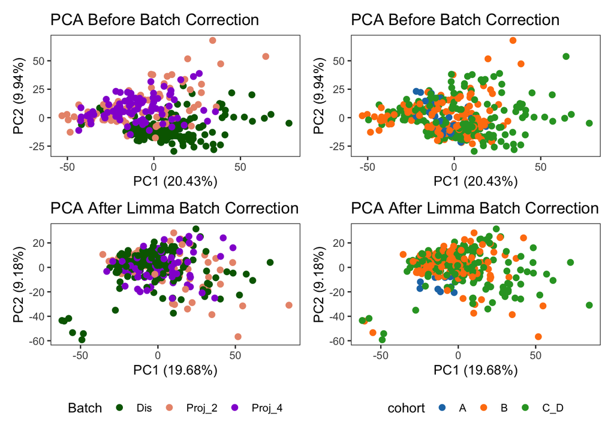

```r
p_all <- p1.1 + p1.2 + p2.1 + p2.2 + plot_layout(ncol=2)
p_all
```

```r
ggsave(filename=file.path(wd$outCurr, "PCA_beforeAfter.pdf"), device="pdf", width=9, height=8)
```

# 7 Obj 3: Perform bridging

Lets do bridging analysis. We follow the workflow on Olink website - https://cran.r-project.org/web//packages/OlinkAnalyze/vignettes/bridging_introduction.html

The bridging analysis only works with 2 dataset. Because we want to bridge between 3 datasets, we need to do the bridging twice.

## 7.1 Q-13356 + Q-15806

```r
xx1 <- dat2_final
xx2 <- dat3_final

xx1 <- xx1 %>%
  mutate(SampleID = paste0("Q_13356_", SampleID))

xx2 <- xx2 %>%
  mutate(SampleID = paste0("Q_15806_", SampleID))

# Identify bridging samples
hci_ids_br1 <- df_meta_f %>% filter(Q_13356 == "Y") %>% pull(HCI_cID)
hci_ids_br2 <- df_meta_f %>% filter(Q_15806 == "Y") %>% pull(HCI_cID)
int_ids <- intersect(hci_ids_br1, hci_ids_br2)


df_ints <- df_meta_f %>% filter(HCI_cID %in% int_ids)

br_1 <- df_ints %>% pull(sample_id_Q13356) %>% paste0("Q_13356_", .)
br_2 <- df_ints %>% pull(sample_id_Q15806) %>% paste0("Q_15806_", .)


overlap_sample_list <-list("DF1" = br_1,
                           "DF2" = br_2)

xx1.1 <- xx1 #%>% select(SampleID, OlinkID, UniProt, NPX, Panel, cohort)
xx2.1 <- xx2 #%>% select(SampleID, OlinkID, UniProt, NPX, Panel, cohort)


# Perform Bridging normalization
npx_br_data <- olink_normalization(
  df1 = xx1.1,
  df2 = xx2.1,
  overlapping_samples_df1 = br_1,
  overlapping_samples_df2 = br_2,
  df1_project_nr = "data1",
  df2_project_nr = "data2",
  reference_project = "data1")
```

## 7.2 Q-13356 + Psomagen

```r
xx1 <- dat2_final
xx2 <- dat1_final

xx1 <- xx1 %>%
  mutate(SampleID = paste0("Q_13356_", SampleID))

xx2 <- xx2 %>%
  mutate(SampleID = paste0("Ps_", SampleID))

# Identify bridging samples
hci_ids_br1 <- df_meta_f %>% filter(Q_13356 == "Y") %>% pull(HCI_cID)
hci_ids_br2 <- df_meta_f %>% filter(Psomagen == "Y") %>% pull(HCI_cID)
int_ids <- intersect(hci_ids_br1, hci_ids_br2)


df_ints <- df_meta_f %>% filter(HCI_cID %in% int_ids)

br_1 <- df_ints %>% pull(sample_id_Q13356) %>% paste0("Q_13356_", .)
br_2 <- df_ints %>% pull(sample_id_psom) %>% paste0("Ps_", .)


overlap_sample_list <-list("DF1" = br_1,
                           "DF2" = br_2)

xx1.1 <- xx1 #%>% select(SampleID, OlinkID, UniProt, NPX, Panel, cohort)
xx2.1 <- xx2 #%>% select(SampleID, OlinkID, UniProt, NPX, Panel, cohort)


# Perform Bridging normalization
npx_br_data2 <- olink_normalization(
  df1 = xx1.1,
  df2 = xx2.1,
  overlapping_samples_df1 = br_1,
  overlapping_samples_df2 = br_2,
  df1_project_nr = "data1",
  df2_project_nr = "data3",
  reference_project = "data1")
```

## 7.3 Final analysis

Here we bridge across 3 cohorts, We simply combine the bridged NPX values.

```r
b1 <- npx_br_data
b2 <- npx_br_data2 %>% filter(!Project == "data1") %>%  # Remove data from project 1
  mutate(Project = gsub("data2", "data3", Project),
         SampleID = gsub("data2", "data3", SampleID))

b1_sub <- b1 %>% select(SampleID, OlinkID, Assay, NPX, cohort)
b2_sub <- b2 %>% select(SampleID, OlinkID, Assay, NPX, cohort)

npx_all <- rbind(b1_sub, b2_sub)
```

We can see that technical replicates are kept.

For example

```r
length(unique(npx_all$SampleID))
```

So for the samples with repeated measurement, we want to just keep 1. We already removed project Q-13356 data from the 2nd round of bridging (Q-13356 + Psomagen). We may have Psomagen and Q-15806 duplicate values

```r
meta_data %>% filter(Rep == "Rep_20") %>% .[,1:5]

npx_all %>% select(SampleID) %>% distinct() %>% filter(SampleID == "data1Q_13356_87")
npx_all %>% select(SampleID) %>% distinct() %>% filter(SampleID == "data2Q_15806_52")
npx_all %>% select(SampleID) %>% distinct() %>% filter(SampleID == "Ps_73")
```

```r
df <- df_meta_f %>%
  mutate(
    sample_id_psom = paste0("Ps_", sample_id_psom),
    sample_id_psom = case_when(sample_id_psom == "Ps_NA" ~ NA, TRUE ~ sample_id_psom),
    # sample_id_Q13356 = paste0("data1Q_13356_", sample_id_Q13356),
    # sample_id_Q13356 = case_when(sample_id_Q13356 == "data1Q_13356_NA" ~ NA, TRUE ~ sample_id_Q13356),
    # sample_id_Q15806 = paste0("data2Q_15806_", sample_id_Q15806),
    # sample_id_Q15806 = case_when(sample_id_Q15806 == "data2Q_15806_NA" ~ NA, TRUE ~ sample_id_Q15806),
    sample_id_Q13356 = paste0("Q_13356_", sample_id_Q13356),
    sample_id_Q13356 = case_when(sample_id_Q13356 == "Q_13356_NA" ~ NA, TRUE ~ sample_id_Q13356),
    sample_id_Q15806 = paste0("Q_15806_", sample_id_Q15806),
    sample_id_Q15806 = case_when(sample_id_Q15806 == "Q_15806_NA" ~ NA, TRUE ~ sample_id_Q15806),
    final_sample_id = coalesce(sample_id_psom, sample_id_Q13356, sample_id_Q15806))
length(unique(df$final_sample_id))
```

## 7.4 PCA

Quick PCA analysis

Lets subset to the samples of interest

```r
npx_all_sub <- npx_all %>%
  filter(SampleID %in% df$final_sample_id)

length(unique(npx_all$SampleID))
length(unique(npx_all_sub$SampleID))
```

Lets subset to overlapping proteins for PCA analysis

```r
ggvenn(
  x,
  fill_color = pal.cohort.n2,
  show_percentage = FALSE,
  stroke_size = 0.5, set_name_size = 4
)

npx_all_sub <- npx_all_sub %>% filter(OlinkID %in% overlap$a5)
```

Run PCA

```r
### PCA plot
p_pca_bridge_all <-
  npx_all_sub %>%
  filter(!str_detect(SampleID, 'CS')) %>%
  olink_pca_plot(df = .,
                 color_g = "cohort", byPanel = FALSE, quiet = FALSE)
```

Make the colour nicer

```r
# Extract metadata
# Subset to columns of interest
df_sub <- df %>% select(mrn, HCI_cID, txt_stat, final_sample_id) %>%
  distinct() %>%
  rename(SampleID = final_sample_id)

# Extract PCA coordinate
pca_cor_b_all <- p_pca_bridge_all[[1]]$data %>%
  rename(PC1 = PCX,
         PC2 = PCY) %>%
  mutate(Batch = gsub("data1.*", "Q_13356", SampleID),
         Batch = gsub("data2.*", "Q_15806", Batch),
         Batch = gsub("Ps.*", "Psomagen", Batch)
         # SampleID = gsub("data1", "", SampleID),
         # SampleID = gsub("data2", "", SampleID),
         # SampleID = gsub("data3", "", SampleID),
         ) %>%
  # Combine with additional metadata
  left_join(df_sub) %>%
  rename(cohort = colors)
```

Make the plot

```r
p3.1 <-
ggplot(pca_cor_b_all, aes(x = PC1, y = PC2, color = Batch)) +
  geom_point(size = pt_sz) +
  labs(
    title = "PCA After Olink Batch Correction",
    x = p_pca_bridge_all[[1]]$labels$x,
    y = p_pca_bridge_all[[1]]$labels$y) +
  theme_bw() +
  theme_custom +
  theme(legend.position = "none") +
  scale_colour_manual(values = pal.study) +
  NULL

p3.2 <-
ggplot(pca_cor_b_all, aes(x = PC1, y = PC2, color = cohort)) +
  geom_point(size = pt_sz) +
  labs(
    title = "PCA After Olink Batch Correction",
    x = p_pca_bridge_all[[1]]$labels$x,
    y = p_pca_bridge_all[[1]]$labels$y) +
  theme_bw() +
  theme_custom +
  theme(legend.position = "none") +
  scale_colour_manual(values = pal.cohort.n2) +
  NULL
```

Show all PCA plot

```r
p1.1 + p1.2 +
p3.1 + p3.2 +
p2.1 + p2.2 + plot_layout(ncol=2)
```

[output not shown]

# 8 Save objects

```r
save(
  exprMatrix_corrected2, exprMatrix_corrected_sub,
  file = file.path(wd$outData, "06_data.Rdata"))
```